# 20BRS1176_George Mathew EDA LAB2 L55+L56 slot

Question 1. Perform multi linear regression on mtcars dataset.

```r
data("mtcars")
dat=mtcars[,c("mpg","disp","hp","wt")]
head(dat)
```

|  | mpg | disp | hp | wt |
| --- | --- | --- | --- | --- |
| Mazda RX4 | 21.0 | 160 | 110 | 2.620 |
| Mazda RX4 Wag | 21.0 | 160 | 110 | 2.875 |
| Datsun 710 | 22.8 | 108 | 93 | 2.320 |
| Hornet 4 Drive | 21.4 | 258 | 110 | 3.215 |
| Hornet Sportabout | 18.7 | 360 | 175 | 3.440 |
| Valiant | 18.1 | 225 | 105 | 3.460 |

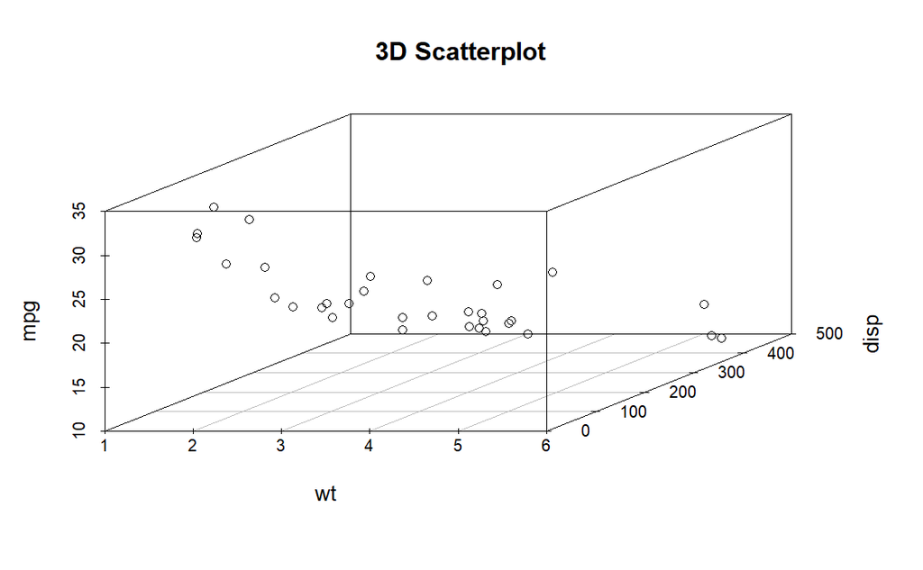

```r
library(scatterplot3d)
attach(mtcars)
scatterplot3d(wt,disp,mpg,main="3D Scatterplot")
```

```r
mod=lm(mpg~wt+disp)
mod
```

```
Call:
lm(formula = mpg ~ wt + disp)

Coefficients:
(Intercept)           wt         disp
   34.96055     -3.35083     -0.01772
```

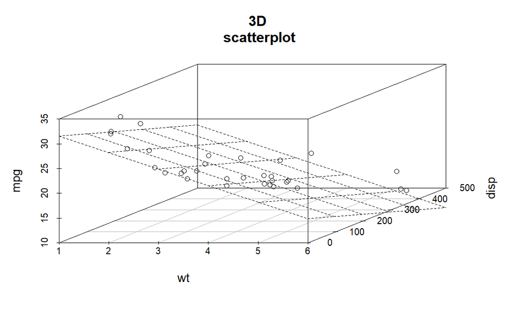

```r
scr = scatterplot3d(wt,disp,mpg,main="3D
scatterplot")
scr$plane3d(mod)
```

Question 2: In a random sample of 6 students each from the CSE major branch of 2014 and 2020, each student was asked about their salary package after they completed graduation. We wanted to know if the typical salary offered after graduation had changed over the past 6 years.

```r
b2014=c(667,859,1129,500,1098,1036)
b2020=c(920,1060,800,645,869,1101)
x1b=mean(b2014)
x2b=mean(b2020)
s1=sd(b2014)
s2=sd(b2020)
n1=length(b2014)
n2=length(b2020)
```

```r
diff_in_means=x1b-x2b
SE_diff_mean=sqrt((s1^2/n1)+(s2^2/n2))
t_stat=diff_in_means/SE_diff_mean
t_stat
```

```
[1] -0.1416828
```

```r
pval=2*pt(t_stat,df=n1+n2-2)
pval
```

```
[1] 0.8901443
```

Interpretation: Hence, we got the p value as 0.89 which is greater than the default assumption. By this we can say that there is not much difference between the mean pay offered to students in 2014 and 2020.

Question 3: Testing of hypothesis(z proportion) A. Out of a sample of 1000 people, 300 watched movies in theatres before the pandemic. In a sample of 1200 persons, it was discovered that 350 of them watched movies in theatres after the outbreak. We wish to investigate whether there is a decline in theatre attendance following the pandemic at the 5% level of significance.

```r
prop.test(x=c(300,350), n=c(1000,1200),,alternative = "two.sided")
```

```
    2-sample test for equality of proportions with continuity correction

data:  c(300, 350) out of c(1000, 1200)
X-squared = 0.14414, df = 1, p-value = 0.7042
alternative hypothesis: two.sided
95 percent confidence interval:
 -0.03089872  0.04756538
sample estimates:
   prop 1    prop 2
0.3000000 0.2916667
```

B.Perform two-proportion Z-Test

```r
prop.test(x=c(800,900),n=c(1000,1200),alternative ="greater")
```

```
    2-sample test for equality of proportions with continuity correction

data:  c(800, 900) out of c(1000, 1200)
X-squared = 7.4826, df = 1, p-value = 0.003115
alternative hypothesis: greater
95 percent confidence interval:
 0.01983221 1.00000000
sample estimates:
prop 1 prop 2
  0.80   0.75
```

```r
x <- c(45,50,53,58,60)
y <- c(9,8,8,7,5)
#Pearson Method
cor(x,y,method = "pearson")
```

```
[1] -0.9088444
```

```r
#Spearman Method
cor(x,y,method = "spearman")
```

```
[1] -0.9746794
```